# Lista-08

#### QQ-plot

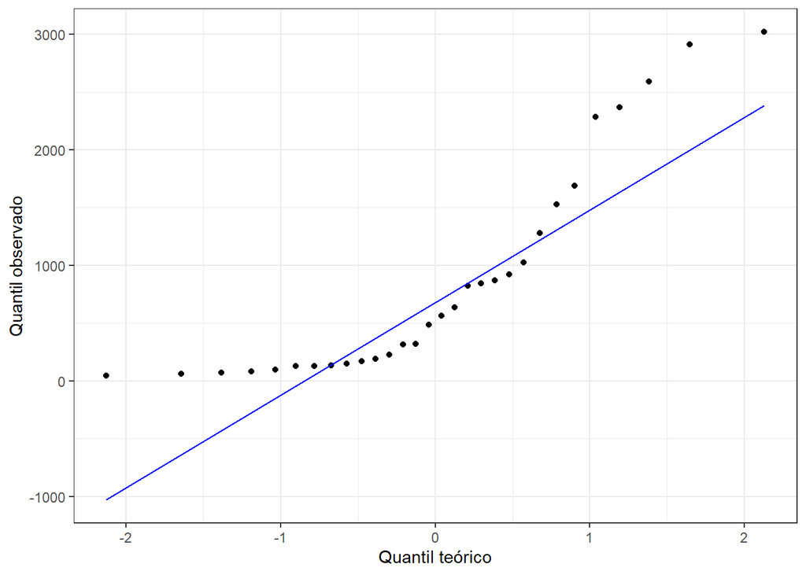

```r
data_set |>
  ggplot(aes(sample = prod)) +
  stat_qq() +
  stat_qq_line(color = "blue") +
  labs(x="Quantil teórico", y="Quantil observado")
```

### Extração das colunas para realizar a analise de variância.

Para realizar a construção do modelo para ANOVA deve-se extrair todas as colunas envolvidas na definição do modelo da anova.

```r
y <- data_set |> pull(prod)
trat <- data_set |>  pull(trat) |> as_factor()
is.factor(trat) # verificando se trat é fator
```

```
## [1] TRUE
```

```r
is.numeric(y) # verificando se y é numérico
```

```
## [1] TRUE
```

### Definição do modelo

O modelo da análise a ser utilizado será o mais simples (Delineamento Inteiramente Casualizado).

$$y_{ij} = \mu + \tau_i +
\epsilon_{ij}$$

Para analisar as pressuposições (Normalidade dos erros e Homocedasticidade), precisamos dos erros, desvios do modelo portanto, utilizamos a função `aov` - para construir o modelo da análise de variância. O resumo da análise com o quadro da ANOVA pode ser acessado com a função `anova`.

```r
mod <- aov(y~trat);mod
```

```
## Call:
##    aov(formula = y ~ trat)
##
## Terms:
##                     trat Residuals
## Sum of Squares  23145259   1768643
## Deg. of Freedom        4        25
##
## Residual standard error: 265.9807
## Estimated effects may be unbalanced
```

```r
anova(mod)
```

```
## Analysis of Variance Table
##
## Response: y
##           Df   Sum Sq Mean Sq F value    Pr(>F)
## trat       4 23145259 5786315   81.79 5.505e-14 ***
## Residuals 25  1768643   70746
## ---
## Signif. codes:  0 '***' 0.001 '**' 0.01 '*' 0.05 '.' 0.1 ' ' 1
```

### Normalidade dos resíduos

Uma vez o modelo salvo, precisamos extrair os resíduos, erros, para testar as pressuposições, estudar os outliers e definir possíveis transformações aos dados.

#### Extrair os resíduos e valores preditos

```r
rs <- rstudent(mod)
```

#### Teste de normalidade

Testando a normalidade dos resíduos e realizando a análise gráfica dos mesmos `install.packages("nortest")` caso necessário.

```r
# Shapiro-Wilks
shapiro.test(rs)
```

```
##
##  Shapiro-Wilk normality test
##
## data:  rs
## W = 0.843, p-value = 0.000444
```

```r
# Kolmogorov-Smirnov
lillie.test(rs)
```

```
##
##  Lilliefors (Kolmogorov-Smirnov) normality test
##
## data:  rs
## D = 0.17133, p-value = 0.02479
```

```r
# Anderson-Darlin
ad.test(rs)
```

```
##
##  Anderson-Darling normality test
##
## data:  rs
## A = 1.5627, p-value = 0.0003996
```

```r
# Cramer-von Mises
cvm.test(rs)
```

```
##
##  Cramer-von Mises normality test
##
## data:  rs
## W = 0.27406, p-value = 0.000591
```

### Estudo de outliers

Os Resíduos brutos são aqueles calculados diretamente a partir do modelo da análise de variância definido, e podem ser acessados com a função `residual``.

Resíduos Padronizados (são os resíduo brutos dividido pelo erro padrão da estimativa dos resíduos). Se os erros têm distribuição normal, então aproximadamente 95% dos resíduos padronizados devem estar no intervalo de (-2,2). Resíduos fora desse intervalo podem indicar a presença de outliers. Utilize a função `rstandard` para calcular esses resíduos.

Resíduos Studentizados são considerados independentes pelo fato de serem resíduos decorrentes de procedimento leave-one-out. Para todos os efeitos, é como se o resíduo padronizado da observação i fosse calculado removendo-se o i-ésimo registro e ajustado o modelo. vantagem é que esses resíduos tem variância constante, (Var(rs) = 1) tornando muito mais fácil a procupra de outliers, ou seja, observações distantes das demais.

Para ilustrar qual resíduo utilizar na análise de resíduos, representar graficamente este gráfico usando os três resíduos, numa mesma figura e observar o que acontece.

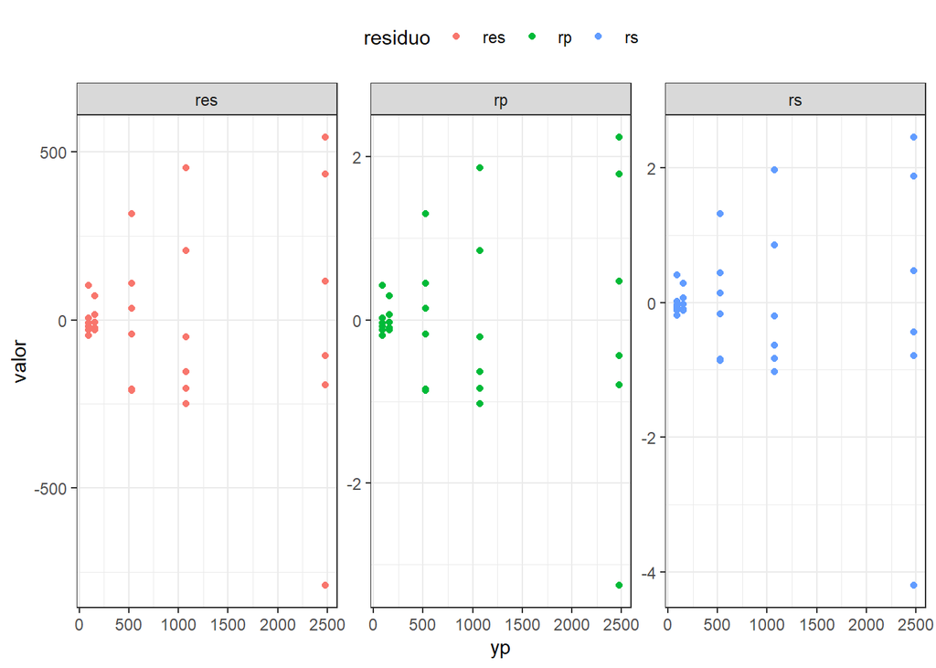

```r
res <- residuals(mod)
rp <- rstandard(mod)
rs <- rstudent(mod)
yp <- predict(mod)

data.frame(res,rp,rs,yp) |>
  pivot_longer(res:rs,names_to = "residuo", values_to = "valor") |>
  ggplot(aes(x=yp, y=valor, color = residuo)) +
  geom_point() +
  facet_wrap(~residuo, scale = "free") +
  theme(
    legend.position = "top"
  )
```

### Homogeneidade das variâncias (homocedasticidade)

Quatro testes podem ser empregados, o teste de Levene, o teste de Brown-Forsythe o teste de Bartlett e Box-Cox

#### Testes de homocedasticidade

```r
# Teste clássico de Levene
levene.test(y,trat,location="mean")
```

```
##
##  Classical Levene's test based on the absolute deviations from the mean
##  ( none not applied because the location is not set to median )
##
## data:  y
## Test Statistic = 5.4711, p-value = 0.002637
```

```r
# Teste Brown-Forsythe
levene.test(y,trat)
```

```
##
##  Modified robust Brown-Forsythe Levene-type test based on the absolute
##  deviations from the median
##
## data:  y
## Test Statistic = 4.5068, p-value = 0.007038
```

```r
#também disponivél no pacote HH
#install.packages("HH")
hov(y~trat)
```

```
##
##  hov: Brown-Forsyth
##
## data:  y
## F = 4.5068, df:trat = 4, df:Residuals = 25, p-value = 0.007038
## alternative hypothesis: variances are not identical
```

```r
# Teste de Bartlett
bartlett.test(y~trat)
```

```
##
##  Bartlett test of homogeneity of variances
##
## data:  y by trat
## Bartlett's K-squared = 29.586, df = 4, p-value = 5.942e-06
```

### Transformação - Bartlett

Se o teste for significativo, ou seja, rejeitamos a hipótese de homocedasticidade, os dados são heterocedasticos. A falta de homogenidade das variâncias pode ser regular ou irregular:

HETEROCEDASTICIDADE IRREGULAR: devemos utilizar um teste não-paramétrico. HETEROCEDASTICIDADE REGULAR: existe uma relação entre a média e a variância utlizamos a tranformação

$$yt = y^{(1-b/2)}$$

onde b é coeficiente angular do modelo de regressão linear entre o log da variância e o log da média de cada tratamento.

```r
# 1) Cálculo do log das variâncias e das médias por tratamentos

# 2) Análise de regressão linear simples de LV em função de LM

# 4) Transformação, se necessária:
# yt<-y^(1-b/2)
```

[output not shown]

#### Transformação - Box - Cox

A transformação Box-Cox é uma das possíveis formas de contornar o problema de dados que não obedecem os pressupostos da análise de variância, como normalidade dos dados.

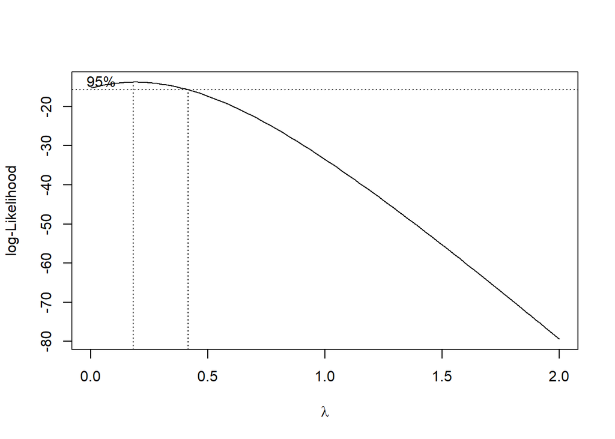

```r
boxcox(mod,seq(0,2,0.2))
```

+ se lambda não difere de 1: Dados são homocedásticos  
+ se lambda difere de 1 (Transformação:

$$\begin{cases}
yt = y^\lambda: \text{se lambda difere de 0} \\
yt = \log{y}: \text{se lambda não difere de 0}
\end{cases}$$

## A análise de variância

$$CV =
\frac{\sqrt{QM_{res}}}{\hat{m}}$$

### Procedimento Para Comparação Múltiplas

Quando não se tem qualquer informação a priori sobre os tratamentos, sugere-se “comparações múltiplas”. Os testes mais comuns para Comparações Múltiplas são:

- Tukey;
- Duncan;
- Student Newman Keuls (SNK);
- t Student (LSD);